# Classification of datasets using decission trees

The following example illustrates the classification of the iris data set which is part of the R base installation. It gives measurements of sepal length, sepal width, petal length and petal width for 50 flowers of the species Iris setosa, Iris versicolor, and Iris virginica.

In order to make visual things easier, Iris setosa is abbrevated as “S”, Iris versicolor as “C”, and Iris virginica as “G”. This is what is done in the following lines.

```r
data(iris)
iris$Label <- substr(iris$Species, 1, 3)
iris$Label <- replace(iris$Label, which(iris$Label=="set"), "S")
iris$Label <- replace(iris$Label, which(iris$Label=="ver"), "C")
iris$Label <- replace(iris$Label, which(iris$Label=="vir"), "G")
```

Since we want to predict the species based on the width/length variables, let’s first have a look if we can identify seperated clusters of classes. For simplicity, only the case of sepal length vs. width and petal legnth vs. width is visualized.

```r
library(latticeExtra)
```

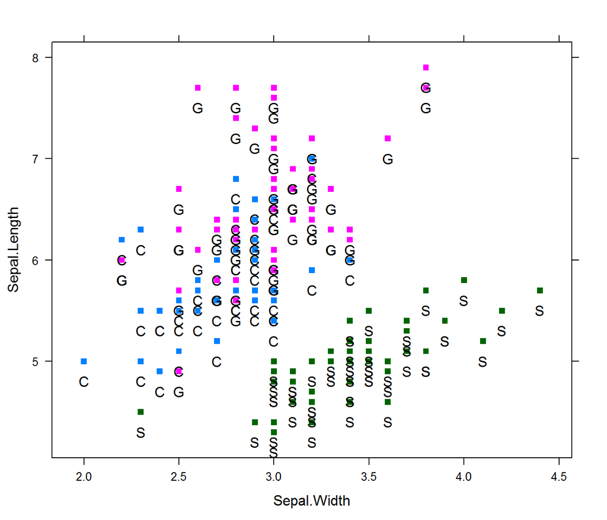

```r
xyplot(Sepal.Length ~ Sepal.Width, data = iris, groups = iris$Label, pch = 15,
       panel=function(x, y, ...){
         panel.xyplot(x, y, ...);
         ltext(x=x, y=y, labels=iris$Label, pos=1, offset=1, cex=1.0)
       })
```

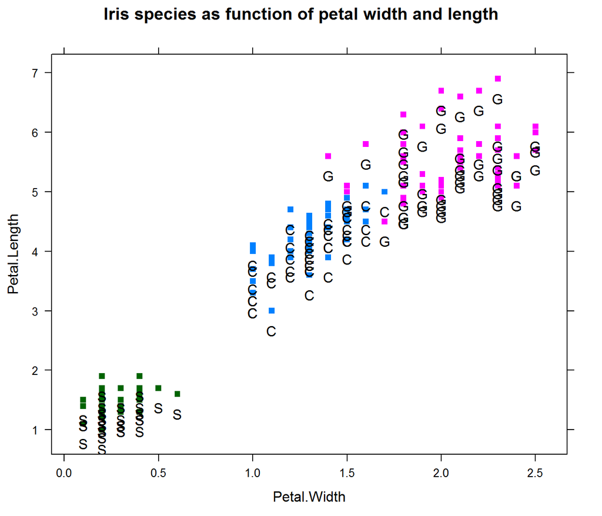

```r
xyplot(Petal.Length ~ Petal.Width, data = iris, groups = iris$Label, pch = 15,
       main = "Iris species as function of petal width and length",
       panel=function(x, y, ...){
         panel.xyplot(x, y, ...);
         ltext(x=x, y=y, labels=iris$Label, pos=1, offset=1, cex=1.0)
       })
```

While the sepal parameters do not clearly separate the species, the pental measurements show a very good seperation between S and C and G while the latter two species are overlaping to some extend.

Let’s see how a decission tree performs on that data set.

```r
library(rpart)
pred <- rpart(Label ~ Sepal.Length + Sepal.Width + Petal.Length + Petal.Width,
              data=iris, method="class")
printcp(pred)
```

```
##
## Classification tree:
## rpart(formula = Label ~ Sepal.Length + Sepal.Width + Petal.Length +
##     Petal.Width, data = iris, method = "class")
##
## Variables actually used in tree construction:
## [1] Petal.Length Petal.Width
##
## Root node error: 100/150 = 0.67
##
## n= 150
##
##     CP nsplit rel error xerror  xstd
## 1 0.50      0      1.00   1.16 0.051
## 2 0.44      1      0.50   0.60 0.060
## 3 0.01      2      0.06   0.09 0.029
```

As evident from the complexity parameter table function, only the variables Petal.Length and Petal.Width are used by the final tree. The cross validation error (column xerror) is continously decreasing over the depth of the tree which starts at level 1 (first row) and ends at level 3 (third row). This can also be seen in the respective plot.

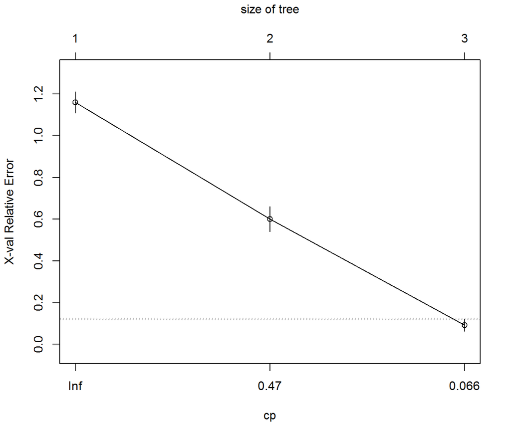

```r
plotcp(pred)
```

A cross validation error of 0.09 is something we can live with for the moment. So let’s have a look at the tree.

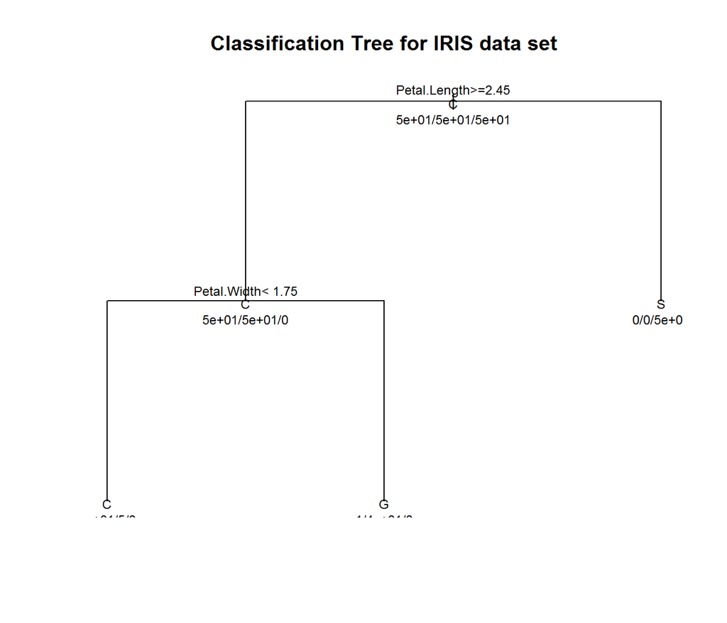

```r
plot(pred, uniform=TRUE, main="Classification Tree for IRIS data set")
text(pred, use.n=TRUE, all=TRUE, cex=0.75)
```

As evident from the petal plot above, species S can be clearly distinguished by a petal length threshold of 2.45. For species C and G the seperation is not optimal and C will also be predicted for 5 of the G species (node 4) while G will be falsly predicted for 1 C species (node 5).

In terms of the petal width vs. length plot, this decission tree can be visualized using one pair of horizontal and vertical line which represents the threshold values of the nodes.

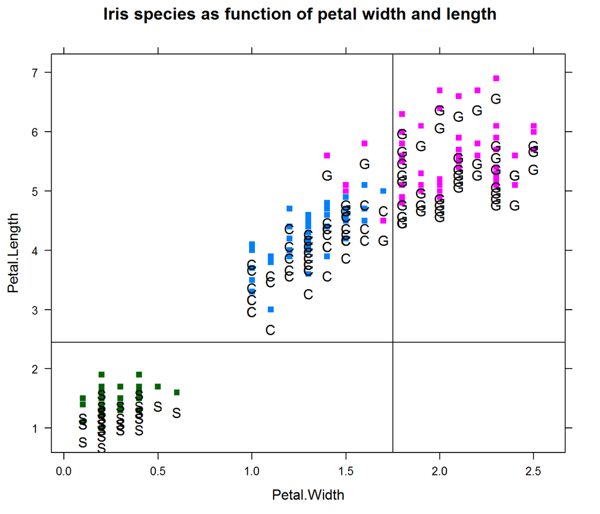

```r
xyplot(Petal.Length ~ Petal.Width, data = iris, groups = iris$Label, pch = 15,
       main = "Iris species as function of petal width and length",
       panel=function(x, y, ...){
         panel.xyplot(x, y, ...);
         panel.abline(h = 2.45);
         panel.abline(v = 1.75);
         ltext(x=x, y=y, labels=iris$Label, pos=1, offset=1, cex=1.0)
       })
```

To get a very detailed view of the decision structure one can also have a look at the summary of the decission tree object. It shows the decision at each node but of course, the graphical representation above is much nicer vor human beings.

```r
summary(pred)
```

```
## Call:
## rpart(formula = Label ~ Sepal.Length + Sepal.Width + Petal.Length +
##     Petal.Width, data = iris, method = "class")
##   n= 150
##
##     CP nsplit rel error xerror    xstd
## 1 0.50      0      1.00   1.16 0.05128
## 2 0.44      1      0.50   0.60 0.06000
## 3 0.01      2      0.06   0.09 0.02909
##
## Variable importance
##  Petal.Width Petal.Length Sepal.Length  Sepal.Width
##           34           31           21           14
##
## Node number 1: 150 observations,    complexity param=0.5
##   predicted class=C  expected loss=0.6667  P(node) =1
##     class counts:    50    50    50
##    probabilities: 0.333 0.333 0.333
##   left son=2 (100 obs) right son=3 (50 obs)
##   Primary splits:
##       Petal.Length < 2.45 to the right, improve=50.00, (0 missing)
##       Petal.Width  < 0.8  to the right, improve=50.00, (0 missing)
##       Sepal.Length < 5.45 to the right, improve=34.16, (0 missing)
##       Sepal.Width  < 3.35 to the left,  improve=19.04, (0 missing)
##   Surrogate splits:
##       Petal.Width  < 0.8  to the right, agree=1.000, adj=1.00, (0 split)
##       Sepal.Length < 5.45 to the right, agree=0.920, adj=0.76, (0 split)
##       Sepal.Width  < 3.35 to the left,  agree=0.833, adj=0.50, (0 split)
##
## Node number 2: 100 observations,    complexity param=0.44
##   predicted class=C  expected loss=0.5  P(node) =0.6667
##     class counts:    50    50     0
##    probabilities: 0.500 0.500 0.000
##   left son=4 (54 obs) right son=5 (46 obs)
##   Primary splits:
##       Petal.Width  < 1.75 to the left,  improve=38.970, (0 missing)
##       Petal.Length < 4.75 to the left,  improve=37.350, (0 missing)
##       Sepal.Length < 6.15 to the left,  improve=10.690, (0 missing)
##       Sepal.Width  < 2.45 to the left,  improve= 3.556, (0 missing)
##   Surrogate splits:
##       Petal.Length < 4.75 to the left,  agree=0.91, adj=0.804, (0 split)
##       Sepal.Length < 6.15 to the left,  agree=0.73, adj=0.413, (0 split)
##       Sepal.Width  < 2.95 to the left,  agree=0.67, adj=0.283, (0 split)
##
## Node number 3: 50 observations
##   predicted class=S  expected loss=0  P(node) =0.3333
##     class counts:     0     0    50
##    probabilities: 0.000 0.000 1.000
##
## Node number 4: 54 observations
##   predicted class=C  expected loss=0.09259  P(node) =0.36
##     class counts:    49     5     0
##    probabilities: 0.907 0.093 0.000
##
## Node number 5: 46 observations
##   predicted class=G  expected loss=0.02174  P(node) =0.3067
##     class counts:     1    45     0
##    probabilities: 0.022 0.978 0.000
```

Here one can see that also the sepal parameters have been tested but since they never add an improve over the petal parameters, they are not used in the final tree.

Just as a final note, the party package provides similar functionality but withvery nice visualizations of the trees.

```r
library(party)
tree <- ctree(Species ~ Sepal.Length + Sepal.Width + Petal.Length + Petal.Width,
              data=iris)
print(tree)
```

```
##
##   Conditional inference tree with 4 terminal nodes
##
## Response:  Species
## Inputs:  Sepal.Length, Sepal.Width, Petal.Length, Petal.Width
## Number of observations:  150
##
## 1) Petal.Length <= 1.9; criterion = 1, statistic = 140.264
##   2)*  weights = 50
## 1) Petal.Length > 1.9
##   3) Petal.Width <= 1.7; criterion = 1, statistic = 67.894
##     4) Petal.Length <= 4.8; criterion = 0.999, statistic = 13.865
##       5)*  weights = 46
##     4) Petal.Length > 4.8
##       6)*  weights = 8
##   3) Petal.Width > 1.7
##     7)*  weights = 46
```

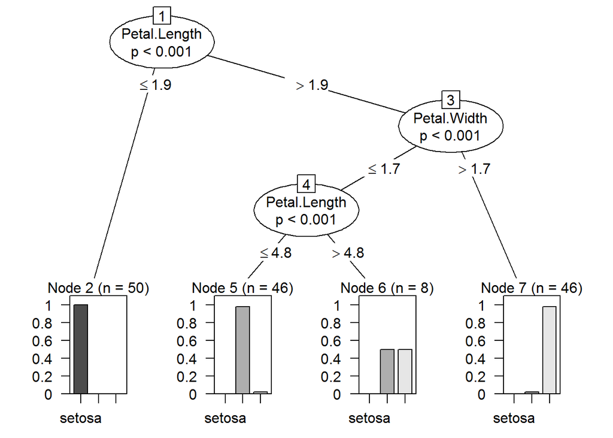

```r
plot(tree)
```